# 2020 MMA Datathon - Medical Insurance Fraud Investigation

Junduo Dong

10/18/2020

##### This is the R markdown file for 2020 MMA Online Datathon.

##### Team name: Team Hortons

##### Team members: Minke Wang, Yuqing Sun, Lily(Lan Xiazi) Liu, Junduo Dong

##### The Following R-code provide data pre-process, feature engineering and modeling

### beneficiary table pre-processing

- Calculate each beneficiaty’s age
- Convert RenalDisease to integer with level 1 and 0
- Convert Chronic_X to integer with level 2 and 0
- Create Deadflag indicates whether a beneficairy has passed away

```r
# I.Calculate each beneficiaty's age by subtract DOB with DOD
library(lubridate)

beneficiary$DOB <- ymd(beneficiary$DOB)
beneficiary$DOD <- ymd(beneficiary$DOD)
beneficiary$Age <- as.integer(round((beneficiary$DOD - beneficiary$DOB)/365,0))
```

```r
# II.As the last DOD is '2009-12-01', which means beneficiary details is of year 2009
# so we calculate age of other beneficiaries as of year 2009
beneficiaryDate <- as.Date("2009-12-01","%Y-%m-%d")
beneficiary$Age <- ifelse(!is.na(beneficiary$Age),beneficiary$Age,
                          round((beneficiaryDate - beneficiary$DOB)/365,0))
```

```r
# III.RenalDisease
beneficiary$RenalDisease <- as.integer(ifelse(beneficiary$RenalDisease == '0', '0','1'))
```

```r
# IV.Chronic_X
Chronic <- grep("^Chronic_", names(beneficiary), value = TRUE)
for (i in 1: length(names(beneficiary[,Chronic]))) {
  beneficiary[,Chronic] <- ifelse(beneficiary[Chronic[i]] == 2,2,0)
}
```

```r
# V.Death Flag
beneficiary$DeadFlag <- as.integer(ifelse(!is.na(beneficiary$DOD),1,0))

# We can remove DOD and DOB for further analysis since we had use them to compute beneficiary's age and dead-flag
```

```r
# check beneficiary data
head(beneficiary)
```

|  | BID | DOB | DOD | Gender | Race | RenalDisease | State | County | NumOfMonths_PartACov | NumOfMonths_PartBCov | Chronic_Alzheimer | Chronic_Heartfailure | Chronic_KidneyDisease | Chronic_Cancer | Chronic_ObstrPulmonary | Chronic_Depression | Chronic_Diabetes | Chronic_IschemicHeart | Chronic_Osteoporasis | Chronic_rheumatoidarthritis | Chronic_stroke | InpatientAnnualReimbursementAmt | InpatientAnnualDeductibleAmt | OutpatientAnnualReimbursementAmt | OutpatientAnnualDeductibleAmt | Age | DeadFlag |
| --- | --- | --- | --- | --- | --- | --- | --- | --- | --- | --- | --- | --- | --- | --- | --- | --- | --- | --- | --- | --- | --- | --- | --- | --- | --- | --- | --- |
| 1 | BENE11001 | 1943-01-01 |  | 1 | 1 | 0 | 39 | 230 | 12 | 12 | 0 | 0 | 0 | 0 | 0 | 0 | 0 | 0 | 0 | 0 | 0 | 36000 | 3204 | 60 | 70 | 67 | 0 |
| 2 | BENE11002 | 1936-09-01 |  | 2 | 1 | 0 | 39 | 280 | 12 | 12 | 2 | 2 | 2 | 2 | 2 | 2 | 2 | 2 | 2 | 2 | 2 | 0 | 0 | 30 | 50 | 73 | 0 |
| 3 | BENE11003 | 1936-08-01 |  | 1 | 1 | 0 | 52 | 590 | 12 | 12 | 0 | 0 | 0 | 0 | 0 | 0 | 0 | 0 | 0 | 0 | 0 | 0 | 0 | 90 | 40 | 73 | 0 |
| 4 | BENE11004 | 1922-07-01 |  | 1 | 1 | 0 | 39 | 270 | 12 | 12 | 0 | 0 | 0 | 0 | 0 | 0 | 0 | 0 | 0 | 0 | 0 | 0 | 0 | 1810 | 760 | 87 | 0 |
| 5 | BENE11005 | 1935-09-01 |  | 1 | 1 | 0 | 24 | 680 | 12 | 12 | 2 | 2 | 2 | 2 | 2 | 2 | 2 | 2 | 2 | 2 | 2 | 0 | 0 | 1790 | 1200 | 74 | 0 |
| 6 | BENE11006 | 1976-09-01 |  | 2 | 1 | 0 | 23 | 810 | 12 | 12 | 2 | 2 | 2 | 2 | 2 | 2 | 2 | 2 | 2 | 2 | 2 | 0 | 0 | 500 | 0 | 33 | 0 |

### inpatients table pre-processing

- Calculate total claim days for each patients’ with their claim
- Calculate admit days only for inpatients
- Calculate number of diagnosis, procedures and physicians
- Calculate number of BID and CID under each distinct PID
- Calculate distint number of BID and CID under each distinct PID
- Use raw number minus distinct number to get number of duplicates of BID and CID under each distinct PID

```r
# I.calculate date period for claim
inpatients$ClaimDays <- as.integer(ymd(inpatients$EndDt) - ymd(inpatients$StartDt))
```

```r
# II.calculate how many days each patient has been stayed in the hospital
inpatients$AdmissionDt <- ymd(inpatients$AdmissionDt)
inpatients$DischargeDt <- ymd(inpatients$DischargeDt)
inpatients$Admitdays <- as.integer(inpatients$DischargeDt - inpatients$AdmissionDt + 1)
```

Count number of Diagnosis and Procedure: Since DiagnosisCode_X and ProcedureCode_X are codes, it’s hard to fill-in with NA. However, we can count number of Diagnosis and Procedure each inpatient beneficiary has

```r
# III.Number of Diagnosis
library(dplyr)
Diagnosis <- grep("^DiagnosisCode_", names(inpatients), value = TRUE)
inpatientsNumberOfDiagnosis1or0 <- function(df){
  df[,Diagnosis] <- lapply(df[,Diagnosis], function(x) as.integer(ifelse(is.na(x),0,1)))
  return(df)
}
inpatients_Diagnosis <- inpatientsNumberOfDiagnosis1or0(inpatients)
inpatients$NumberOfDiagnosis <- inpatients_Diagnosis %>% select(Diagnosis) %>% rowSums
inpatients_Diagnosis <- NULL
```

```r
# IV.Number of Procedures
Procedure <- grep("^ProcedureCode_", names(inpatients), value = TRUE)
inpatientsNumberofProcedure1or0 <- function(df){
  df[,Procedure] <- lapply(df[,Procedure], function(x) as.integer(ifelse(is.na(x),0,1)))
  return(df)
}
inpatients_Procedure <- inpatientsNumberofProcedure1or0(inpatients)
inpatients$NumberOfProcedures <- inpatients_Procedure %>% select(Procedure) %>% rowSums
inpatients_Procedure <- NULL
```

```r
# V.Number of Physicians
Physicians <- c("AttendingPhysician","OperatingPhysician","OtherPhysician")
NumberOfPhysicians1or0 <- function(df){
  df[,Physicians] <- lapply(df[,Physicians], function(x) as.integer(ifelse(is.na(x),0,1)))
  return(df)
}
inpatients_Physicians <- NumberOfPhysicians1or0(inpatients)
inpatients$NumberOfPhysicians <- inpatients_Physicians %>% select(Physicians) %>% rowSums
inpatients_Physicians <- NULL
```

```r
# VI. Number of BID and CID under each PID
inpatients_PIDBID <- inpatients %>% select(BID,PID) %>% group_by(PID) %>% summarise(NumberOfBID = n())
inpatients <- merge(inpatients,inpatients_PIDBID,by = "PID")
inpatients_PIDBID <- NULL
inpatients_PIDCID <- inpatients %>% select(CID,PID) %>% group_by(PID) %>% summarise(NumberOfCID = n())
inpatients <- merge(inpatients,inpatients_PIDCID, by = "PID")
inpatients_PIDCID <- NULL
```

```r
# VII. Number of distinct BID and CID under each PID and (BID - distinct BID) & (CID - distinct CID)
inpatients_distinctPIDBID <- inpatients %>% select(BID,PID) %>% group_by(PID) %>% summarise(NumberOfDistinctBID = n_distinct(BID))
inpatients <- merge(inpatients,inpatients_distinctPIDBID,by = "PID")
inpatients_distinctPIDBID <- NULL
inpatients_distinctPIDCID <- inpatients %>% select(CID,PID) %>% group_by(PID) %>% summarise(NumberOfDistinctCID = n_distinct(CID))
inpatients <- merge(inpatients,inpatients_distinctPIDCID,by = "PID")
inpatients_distinctPIDCID <- NULL

# Calculate number of duplicates by subtract raw numbers with distinct numbers for BID and CID
inpatients$`Number of BID - Number of DisitnctBID` <- inpatients$NumberOfBID - inpatients$NumberOfDistinctBID
inpatients$`Number of CID - Number of DisitnctCID` <- inpatients$NumberOfCID - inpatients$NumberOfDistinctCID
```

```r
# check inpatient data
head(inpatients)
```

|  | PID | BID | CID | StartDt | EndDt | AmtReimbursed | AttendingPhysician | OperatingPhysician | OtherPhysician | AdmissionDt | AdmitDiagnosisCode | DeductibleAmt | DischargeDt | DiagnosisGroupCode | DiagnosisCode_1 | DiagnosisCode_2 | DiagnosisCode_3 | DiagnosisCode_4 | DiagnosisCode_5 | DiagnosisCode_6 | DiagnosisCode_7 | DiagnosisCode_8 | DiagnosisCode_9 | DiagnosisCode_10 | ProcedureCode_1 | ProcedureCode_2 | ProcedureCode_3 | ProcedureCode_4 | ProcedureCode_5 | … |
| --- | --- | --- | --- | --- | --- | --- | --- | --- | --- | --- | --- | --- | --- | --- | --- | --- | --- | --- | --- | --- | --- | --- | --- | --- | --- | --- | --- | --- | --- | --- |
| 1 | PRV51001 | BENE152088 | CLM37205 | 2009-02-06 | 2009-02-06 | 4000 | PHY402229 | PHY329739 | NA | 2009-02-06 | 80121 | 1068 | 2009-02-06 | 062 | 85222 | 2724 | 3310 | 40390 | V4501 | V5866 | NA | NA | NA | NA | 8659 | NA | NA | NA | NA | … |
| 2 | PRV51001 | BENE36012 | CLM58316 | 2009-07-04 | 2009-07-08 | 36000 | PHY340163 | NA | NA | 2009-07-04 | 29623 | 1068 | 2009-07-08 | 882 | 29650 | 2971 | 3051 | V1254 | 07070 | 28260 | 7823 | 49300 | NA | NA | NA | NA | NA | NA | NA | … |
| 3 | PRV51001 | BENE102690 | CLM49733 | 2009-05-04 | 2009-05-18 | 42000 | PHY383193 | PHY378091 | PHY389113 | 2009-05-04 | 41401 | 1068 | 2009-05-18 | 245 | 4241 | 42731 | 4168 | 2724 | 4019 | 42822 | 2720 | 45829 | 53081 | NA | 3521 | 2724 | NA | NA | NA | … |
| 4 | PRV51001 | BENE38773 | CLM52334 | 2009-05-23 | 2009-05-25 | 12000 | PHY346762 | NA | NA | 2009-05-23 | 0389 | 1068 | 2009-05-25 | 864 | 0388 | 5849 | 2841 | 2762 | 7140 | E9444 | NA | NA | NA | NA | NA | NA | NA | NA | NA | … |
| 5 | PRV51001 | BENE98831 | CLM36844 | 2009-02-03 | 2009-02-08 | 3000 | PHY383193 | NA | NA | 2009-02-03 | 5362 | 1068 | 2009-02-08 | 353 | 56211 | 5533 | 0088 | 5789 | 53081 | 27651 | 7840 | NA | NA | NA | NA | NA | NA | NA | NA | … |
| 6 | PRV51003 | BENE113706 | CLM74421 | 2009-11-02 | 2009-11-09 | 32000 | PHY364445 | PHY397381 | NA | 2009-11-02 | 5789 | 1068 | 2009-11-09 | 385 | 00845 | 44422 | 7907 | 30550 | 5779 | 5854 | 41401 | 45340 | 2851 | NA | 5411 | 5712 | NA | NA | NA | … |

### outpatients table pre-processing

```r
# I.calculate date period for claim
outpatients$ClaimDays <- as.integer(ymd(outpatients$EndDt) - ymd(outpatients$StartDt))

# II. assign number of 0 to admit days to outpatients
outpatients$Admitdays <- 0
```

```r
# III.Number of Diagnosis
Diagnosis2 <- grep("^DiagnosisCode_", names(outpatients), value = TRUE)
outpatientsNumberOfDiagnosis1or0 <- function(df){
  df[,Diagnosis2] <- lapply(df[,Diagnosis2], function(x) as.integer(ifelse(is.na(x),0,1)))
  return(df)
}
outpatients_Diagnosis <- outpatientsNumberOfDiagnosis1or0(outpatients)
outpatients$NumberOfDiagnosis <- outpatients_Diagnosis %>% select(Diagnosis2) %>% rowSums
outpatients_Diagnosis <- NULL
```

```r
# IV.Number of Procedure
Procedure2 <- grep("^ProcedureCode_", names(outpatients), value = TRUE)
outpatientsNumberofProcedure1or0 <- function(df){
  df[,Procedure2] <- lapply(df[,Procedure2], function(x) as.integer(ifelse(is.na(x),0,1)))
  return(df)
}
outpatients_Procedure <- outpatientsNumberofProcedure1or0(outpatients)
outpatients$NumberOfProcedures <- outpatients_Procedure %>% select(Procedure2) %>% rowSums
outpatients_Procedure <- NULL
```

```r
# V.Number of Physicians
outpatients_Physicians <- NumberOfPhysicians1or0(outpatients)
outpatients$NumberOfPhysicians <- outpatients_Physicians %>% select(Physicians) %>% rowSums
outpatients_Physicians <- NULL
```

```r
# VI. Number of BID and CID under each PID
outpatients_PIDBID <- outpatients %>% select(BID,PID) %>% group_by(PID) %>% summarise(NumberOfBID = n())
outpatients <- merge(outpatients, outpatients_PIDBID,by = "PID")
outpatients_PIDBID <- NULL
outpatients_PIDCID <- outpatients %>% select(CID,PID) %>% group_by(PID) %>% summarise(NumberOfCID = n())
outpatients <- merge(outpatients, outpatients_PIDCID,by = "PID")
outpatients_PIDCID <- NULL
```

```r
# VII. Number of distinct BID and CID under each PID and (BID - distinct BID) & (CID - distinct CID)
outpatients_distinctPIDBID <- outpatients %>% select(BID,PID) %>% group_by(PID) %>% summarise(NumberOfDistinctBID = n_distinct(BID))
outpatients <- merge(outpatients,outpatients_distinctPIDBID,by = "PID")
outpatients_distinctPIDBID <- NULL
outpatients_distinctPIDCID <- outpatients %>% select(CID,PID) %>% group_by(PID) %>% summarise(NumberOfDistinctCID = n_distinct(CID))
outpatients <- merge(outpatients,outpatients_distinctPIDCID,by = "PID")
outpatients_distinctPIDCID <- NULL

# Calculate number of duplicates by subtract raw numbers with distinct numbers for BID and CID
outpatients$`Number of BID - Number of DisitnctBID` <- outpatients$NumberOfBID - outpatients$NumberOfDistinctBID
outpatients$`Number of CID - Number of DisitnctCID` <- outpatients$NumberOfCID - outpatients$NumberOfDistinctCID
```

```r
# VIII. DiagnosisGroupCode
outpatients$DiagnosisGroupCode = as.factor(NA)
```

```r
# check outpatient data
head(outpatients)
```

|  | PID | BID | CID | StartDt | EndDt | AmtReimbursed | AttendingPhysician | OperatingPhysician | OtherPhysician | DiagnosisCode_1 | DiagnosisCode_2 | DiagnosisCode_3 | DiagnosisCode_4 | DiagnosisCode_5 | DiagnosisCode_6 | DiagnosisCode_7 | DiagnosisCode_8 | DiagnosisCode_9 | DiagnosisCode_10 | ProcedureCode_1 | ProcedureCode_2 | ProcedureCode_3 | ProcedureCode_4 | ProcedureCode_5 | ProcedureCode_6 | DeductibleAmt | AdmitDiagnosisCode | ClaimDays | Admitdays | … |
| --- | --- | --- | --- | --- | --- | --- | --- | --- | --- | --- | --- | --- | --- | --- | --- | --- | --- | --- | --- | --- | --- | --- | --- | --- | --- | --- | --- | --- | --- | --- |
| 1 | PRV51001 | BENE61975 | CLM260292 | 2009-03-22 | 2009-03-22 | 60 | PHY392882 | NA | PHY392882 | 78901 | 7873 | NA | NA | NA | NA | NA | NA | NA | NA | NA | NA | NA | NA | NA | NA | 0 |  | 0 | 0 | … |
| 2 | PRV51001 | BENE56354 | CLM403535 | 2009-06-08 | 2009-06-08 | 100 | PHY350459 | NA | NA | 5168 | 36250 | 33819 | NA | NA | NA | NA | NA | NA | NA | NA | NA | NA | NA | NA | NA | 0 | 78659 | 0 | 0 | … |
| 3 | PRV51001 | BENE24646 | CLM372475 | 2009-05-22 | 2009-05-23 | 700 | PHY405682 | NA | PHY402512 | 78650 | 51889 | V5869 | 4019 | V4581 | 49320 | NA | NA | NA | NA | NA | NA | NA | NA | NA | NA | 0 |  | 1 | 0 | … |
| 4 | PRV51001 | BENE31617 | CLM748221 | 2009-12-28 | 2009-12-28 | 900 | PHY345302 | NA | NA | V446 | NA | NA | NA | NA | NA | NA | NA | NA | NA | NA | NA | NA | NA | NA | NA | 0 | 59970 | 0 | 0 | … |
| 5 | PRV51001 | BENE156020 | CLM426054 | 2009-06-20 | 2009-06-20 | 400 | PHY402512 | NA | PHY402512 | 5168 | 4019 | 4295 | NA | NA | NA | NA | NA | NA | NA | NA | NA | NA | NA | NA | NA | 0 |  | 0 | 0 | … |
| 6 | PRV51001 | BENE130029 | CLM262535 | 2009-03-23 | 2009-03-23 | 90 | PHY409648 | NA | PHY409648 | 56989 | NA | NA | NA | NA | NA | NA | NA | NA | NA | NA | NA | NA | NA | NA | NA | 0 |  | 0 | 0 | … |

### Check Data Before Merge

- Check dimensionality for outpatients and inpatients table
- Check Surplus between them
- Main Difference between inpatient and outpatients is the ‘Admitdays’, outpatients only has value of 0, whereas inpatients has range from 1 to 36 days
- Drop inpatient’s admissionDt and DischargeDt since they been calculated to ‘Admitdays’
- Convert ProcedureCode_X to proper class

```r
# I. print structures of inpatients and outpatients
print(paste("dimensionality of inpatients dataset: " ,dim(inpatients)[1], "observations", dim(inpatients)[2], "features"))
```

```
## [1] "dimensionality of inpatients dataset:  40474 observations 41 features"
```

```r
print(paste("dimensionality of outpatients dataset: " ,dim(outpatients)[1], "observations", dim(outpatients)[2], "features"))
```

```
## [1] "dimensionality of outpatients dataset:  517737 observations 39 features"
```

```r
# II.Inpatient dataset (surplus): AdmissionDt, DischargeDt, DiagnosisGroupCode
# setdiff(inpatients,outpatients)
```

```r
# III.Inpatient Admit days range from 1 to 36, outpatient equals 0
print(paste("Minimum days of admit: ", min(inpatients$Admitdays)));print(paste("Maximum days of admit: ", max(inpatients$Admitdays)))
```

```
## [1] "Minimum days of admit:  1"
```

```
## [1] "Maximum days of admit:  36"
```

```r
# IV.final conversion and dropout before output
inpatients$AdmissionDt <- NULL
inpatients$DischargeDt <- NULL
inpatients$ProcedureCode_6 <- as.integer(inpatients$ProcedureCode_6)
outpatients$ProcedureCode_5 <- as.integer(outpatients$ProcedureCode_5)
outpatients$ProcedureCode_6 <- as.integer(outpatients$ProcedureCode_6)
```

```r
# write.csv(inpatients,file="/Users/oliverdong/Downloads/MMA 2020/cleaned data/inpatients.csv")
# write.csv(outpatients,file="/Users/oliverdong/Downloads/MMA 2020/cleaned data/outpatients.csv")
# write.csv(beneficiary,file="/Users/oliverdong/Downloads/MMA 2020/cleaned data/beneficiary.csv")
```

### Join/Merge Data

- Merge inpatients and outpatients table
- Calculate mean value of ‘meanMonths_PartACov’ and ‘meanMonths_PartBCov’ and merge them into fullPatientData

```r
# Union inpatient and outpatient data
setwd("~/Downloads/MMA 2020/cleaned data")
beneficiary <- read.csv("beneficiary.csv", header = TRUE)
inpatients <- read.csv("inpatients.csv", header = TRUE)
outpatients <- read.csv("outpatients.csv", header = TRUE)
providers <- read.csv("providers.csv", header = TRUE)
```

```r
inpatients$X <- NULL
outpatients$X <- NULL
beneficiary$X <- NULL
```

```r
# join full patient data from inpatient, outpatient and provider table
fullPatientData <- rbind(inpatients, outpatients)
fullPatientData <- inner_join(fullPatientData, providers, by = 'PID')
# join beneficiary table with BID
fullPatientData2 <- inner_join(fullPatientData,beneficiary, by = "BID")
```

```r
## average coverage for both part A and B under each distinct PID
meanMonths_PartACov <- fullPatientData2 %>% select(PID, NumOfMonths_PartACov) %>% group_by(PID) %>% summarise(meanMonths_PartACov = mean(NumOfMonths_PartACov))
meanMonths_PartBCov <- fullPatientData2 %>% select(PID, NumOfMonths_PartBCov) %>% group_by(PID) %>% summarise(meanMonths_PartBCov = mean(NumOfMonths_PartBCov))
fullPatientData2 <- merge(fullPatientData2, meanMonths_PartACov, by ="PID")
fullPatientData2 <- merge(fullPatientData2, meanMonths_PartBCov, by ="PID")
meanMonths_PartACov <- NULL
meanMonths_PartBCov <- NULL
```

```r
# check fullPatientData data
head(fullPatientData)
```

|  | PID | BID | CID | StartDt | EndDt | AmtReimbursed | AttendingPhysician | OperatingPhysician | OtherPhysician | AdmitDiagnosisCode | DeductibleAmt | DiagnosisGroupCode | DiagnosisCode_1 | DiagnosisCode_2 | DiagnosisCode_3 | DiagnosisCode_4 | DiagnosisCode_5 | DiagnosisCode_6 | DiagnosisCode_7 | DiagnosisCode_8 | DiagnosisCode_9 | DiagnosisCode_10 | ProcedureCode_1 | ProcedureCode_2 | ProcedureCode_3 | ProcedureCode_4 | ProcedureCode_5 | ProcedureCode_6 | ClaimDays | … |
| --- | --- | --- | --- | --- | --- | --- | --- | --- | --- | --- | --- | --- | --- | --- | --- | --- | --- | --- | --- | --- | --- | --- | --- | --- | --- | --- | --- | --- | --- | --- |
| 1 | PRV51001 | BENE152088 | CLM37205 | 2009-02-06 | 2009-02-06 | 4000 | PHY402229 | PHY329739 | NA | 80121 | 1068 | 062 | 85222 | 2724 | 3310 | 40390 | V4501 | V5866 | NA | NA | NA | NA | 8659 | NA | NA | NA | NA | NA | 0 | … |
| 2 | PRV51001 | BENE36012 | CLM58316 | 2009-07-04 | 2009-07-08 | 36000 | PHY340163 | NA | NA | 29623 | 1068 | 882 | 29650 | 2971 | 3051 | V1254 | 07070 | 28260 | 7823 | 49300 | NA | NA | NA | NA | NA | NA | NA | NA | 4 | … |
| 3 | PRV51001 | BENE102690 | CLM49733 | 2009-05-04 | 2009-05-18 | 42000 | PHY383193 | PHY378091 | PHY389113 | 41401 | 1068 | 245 | 4241 | 42731 | 4168 | 2724 | 4019 | 42822 | 2720 | 45829 | 53081 | NA | 3521 | 2724 | NA | NA | NA | NA | 14 | … |
| 4 | PRV51001 | BENE38773 | CLM52334 | 2009-05-23 | 2009-05-25 | 12000 | PHY346762 | NA | NA | 0389 | 1068 | 864 | 0388 | 5849 | 2841 | 2762 | 7140 | E9444 | NA | NA | NA | NA | NA | NA | NA | NA | NA | NA | 2 | … |
| 5 | PRV51001 | BENE98831 | CLM36844 | 2009-02-03 | 2009-02-08 | 3000 | PHY383193 | NA | NA | 5362 | 1068 | 353 | 56211 | 5533 | 0088 | 5789 | 53081 | 27651 | 7840 | NA | NA | NA | NA | NA | NA | NA | NA | NA | 5 | … |
| 6 | PRV51003 | BENE113706 | CLM74421 | 2009-11-02 | 2009-11-09 | 32000 | PHY364445 | PHY397381 | NA | 5789 | 1068 | 385 | 00845 | 44422 | 7907 | 30550 | 5779 | 5854 | 41401 | 45340 | 2851 | NA | 5411 | 5712 | NA | NA | NA | NA | 7 | … |

```r
# save full data
# write.csv(fullPatientData2,file="/Users/oliverdong/Downloads/MMA 2020/cleaned data/fullPatientData.csv")
```

### Feature Engineer and Modeling

- Convert NA value in DiagnosisGroupCode to 0 and 1 (only inpatients claim has diagnosis group code) — Following are aggregation on differnt metrics to PID level
- Patients data: mean value on different continuous variable
- Beneficary data: mean value on different continuous variable
- Beneficary data: sum value on ordinal variables: Renaldisease, Chronic_X, deadflag

```r
setwd("~/Downloads/MMA 2020/cleaned data")
fullPatientData <- read.csv("fullPatientData.csv", header = TRUE)
```

```r
# 1. duplicate fullpatientdata to fullpatientdata2
fullPatientData2 <- fullPatientData
fullPatientData2$DiagnosisGroupCode <- ifelse(is.na(fullPatientData2$DiagnosisGroupCode),0,1)
```

```r
# 2.convert all numeric features to avergae of PID level in patients data
library(dplyr)
data1 <- fullPatientData2 %>% select(PID, Fraud, Number.of.BID...Number.of.DisitnctBID, Number.of.CID...Number.of.DisitnctCID
                                    ,ClaimDays, Admitdays
                                    ,NumberOfDiagnosis, NumberOfProcedures, NumberOfPhysicians
                                    ,AmtReimbursed, DeductibleAmt, DiagnosisGroupCode) %>% group_by(PID,Fraud) %>%
  summarise(# AvgNumofBID = mean(NumberOfBID),
            # AvgNumofCID = mean(NumberOfCID),
            `AvgNumofCID - AvgNumofDistinctCID` = mean(Number.of.CID...Number.of.DisitnctCID),
            `AvgNumofBID - AvgNumofDistinctBID` = mean(Number.of.BID...Number.of.DisitnctBID),
            AvgClaimDays = mean(ClaimDays),
            AvgAdmitDays = mean(Admitdays),
            AvgNumofDiagnosis = mean(NumberOfDiagnosis),
            AvgNumofProcedures = mean(NumberOfProcedures),
            AvgNumofPhysicians = mean(NumberOfPhysicians),
            AvgAmtReimbursed = mean(AmtReimbursed),
            AvgAmtDeductible = mean(DeductibleAmt)
            # AvgDiagnosisGroupCode = mean(DiagnosisGroupCode)
            )
data1 <- as.data.frame(data1)
```

```r
# 3.convert all numeric features to avergae of PID level in beneficiary data
data2 <- fullPatientData2 %>% select(PID, Fraud, Age, NumOfMonths_PartACov, NumOfMonths_PartBCov
                                     ,InpatientAnnualReimbursementAmt
                                     ,InpatientAnnualDeductibleAmt
                                     ,OutpatientAnnualReimbursementAmt
                                     ,OutpatientAnnualDeductibleAmt) %>% group_by(PID,Fraud) %>%
  summarise(AvgAge = mean(Age),
            AvgNumOfMonths_PartACov = mean(NumOfMonths_PartACov),
            AvgNumOfMonths_PartBCov = mean(NumOfMonths_PartBCov),
            AvgInpatientAnnualReimbursementAmt = mean(InpatientAnnualReimbursementAmt),
            AvgInpatientAnnualDeductibleAmt = mean(InpatientAnnualDeductibleAmt),
            AvgOutpatientAnnualReimbursementAmt = mean(OutpatientAnnualReimbursementAmt),
            AvgOutpatientAnnualDeductibleAmt = mean(OutpatientAnnualDeductibleAmt))
data2 <- as.data.frame(data2)
```

```r
# 4. convert all the following features to sum for each distinct PID
# Renaldisease (46), Chronic_X (51:61), deadflag (67)
selectcolumns <- c(2,46,51:61,67)
data3 <- fullPatientData2[,selectcolumns]
data3 <- data3 %>% mutate_if(is.integer, as.integer) %>%
  mutate(NumOfChronic = select(.,contains("Chronic_")) %>% rowSums()) %>%
  select(PID, RenalDisease, DeadFlag, NumOfChronic) %>%
  group_by(PID) %>%
  summarise(SumRenalDisease = sum(RenalDisease),
            SumDeadFlag = sum(DeadFlag),
            SumNumOfChronic = sum(NumOfChronic))
data3$SumNumOfChronic <- data3$SumNumOfChronic/2
```

- These ordinal vaiable contains high dimensionlity from beneficiary.csv will be analysis further in EDA: DiagnosisGroupCode, Gender, Race, State, County

```r
# 5. merge table (data1:data3)

# merge feature engineered patient data and beneficiary data
model_data <- merge(data1,data2,by="PID")
# remove duplicate fraud column and adjust column name
model_data$Fraud.x <- NULL
names(model_data)[11] <- "Fraud"

# merge patient data with other categorical features
model_data <- merge(model_data, data3, by = "PID")

# remove "PID"
model_data$PID <- NULL
# model_data$`AvgNumofCID - AvgNumofDistinctCID` <- NULL

### rename columns
names(model_data)[1] <- "AvgNumofCID_minus_AvgNumofDistinctCID"
names(model_data)[2] <- "AvgNumofBID_minus_AvgNumofDistinctBID"
```

```r
# check model_data data
head(model_data)
```

|  | AvgNumofCID_minus_AvgNumofDistinctCID | AvgNumofBID_minus_AvgNumofDistinctBID | AvgClaimDays | AvgAdmitDays | AvgNumofDiagnosis | AvgNumofProcedures | AvgNumofPhysicians | AvgAmtReimbursed | AvgAmtDeductible | Fraud | AvgAge | AvgNumOfMonths_PartACov | AvgNumOfMonths_PartBCov | AvgInpatientAnnualReimbursementAmt | AvgInpatientAnnualDeductibleAmt | AvgOutpatientAnnualReimbursementAmt | AvgOutpatientAnnualDeductibleAmt | SumRenalDisease | SumDeadFlag | SumNumOfChronic |
| --- | --- | --- | --- | --- | --- | --- | --- | --- | --- | --- | --- | --- | --- | --- | --- | --- | --- | --- | --- | --- |
| 1 | 0 | 0.800000 | 1.4400000 | 1.2000000 | 3.200000 | 0.12000000 | 1.600000 | 4185.6000 | 213.600000 | No | 78.84000 | 12.00000 | 12.00000 | 17606.000 | 897.1200 | 2615.200 | 463.9200 | 8 | 0 | 110 |
| 2 | 0 | 6.348485 | 3.6742424 | 2.8939394 | 5.250000 | 0.36363636 | 1.530303 | 4588.4091 | 502.166667 | Yes | 70.02273 | 11.81818 | 11.87121 | 7568.182 | 931.4242 | 2678.182 | 737.1212 | 29 | 1 | 836 |
| 3 | 0 | 11.000000 | 1.4295302 | 0.0000000 | 2.583893 | 0.00000000 | 1.604027 | 350.1342 | 2.080537 | No | 72.16107 | 11.86577 | 11.95973 | 4351.879 | 434.9530 | 2194.899 | 622.7517 | 23 | 1 | 935 |
| 4 | 0 | 670.000000 | 1.0884120 | 0.0000000 | 2.588841 | 0.00000000 | 1.599142 | 241.1245 | 3.175966 | Yes | 70.47554 | 11.90730 | 11.93991 | 3623.991 | 379.1622 | 2109.734 | 636.3288 | 259 | 4 | 8129 |
| 5 | 0 | 12.458333 | 0.9583333 | 0.2638889 | 2.986111 | 0.01388889 | 1.527778 | 468.1944 | 45.333333 | No | 69.29167 | 11.83333 | 11.83333 | 3050.000 | 445.0000 | 1729.722 | 469.7222 | 11 | 1 | 506 |
| 6 | 0 | 6.674419 | 1.5348837 | 0.2325581 | 3.162791 | 0.04651163 | 1.534884 | 828.6047 | 53.860465 | No | 75.62791 | 12.00000 | 12.00000 | 6592.093 | 620.9302 | 2570.465 | 616.0465 | 10 | 0 | 286 |

### Correlation matrix plot

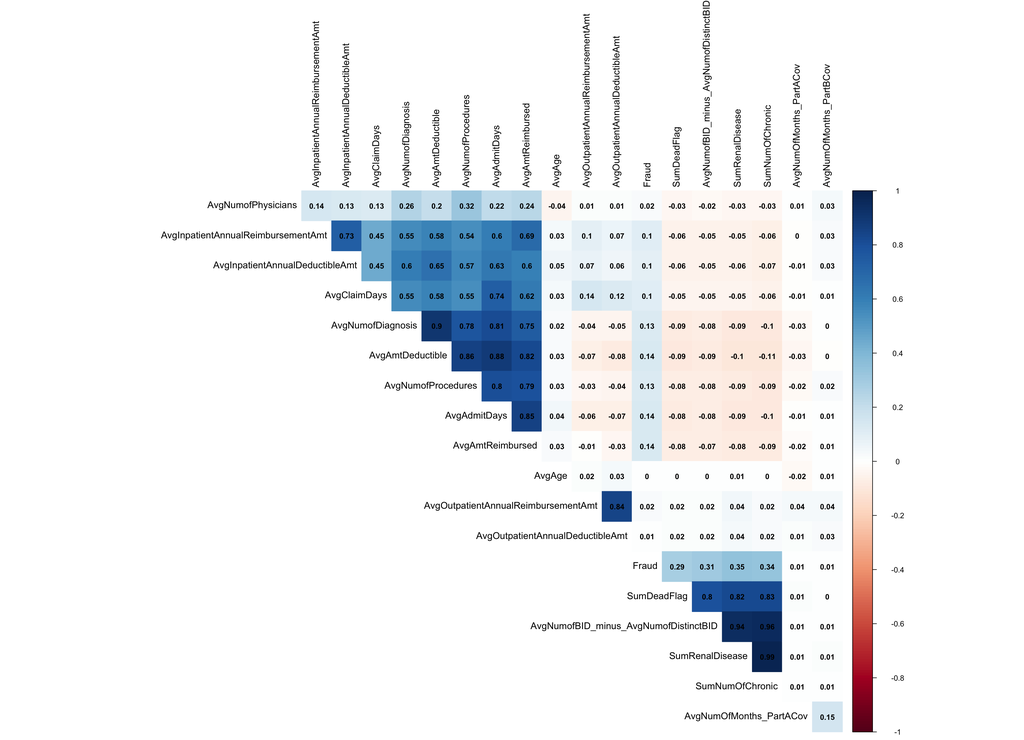

```r
model_data2 <- model_data
model_data2$Fraud <- as.numeric(ifelse(model_data$Fraud == "No",0,1))
model_data2$AvgNumofCID_minus_AvgNumofDistinctCID <- NULL
corr <- cor(model_data2,use = "complete.obs")

library(corrplot)
corrplot(corr,
         # adjust visualization method, display spot and character ordering
         method="color", type = "upper", order = "hclust",
         # add correlation coefficient and adjust text size
         addCoef.col = "black",number.cex = .8,
         # adjust color of corr.coef text
         tl.col = "black",
         diag = FALSE)
```

### Random Forest Model and Feature Importance

```r
# random forest model
split_70percentage <- (.7)
trainingRowIndex_70pct <- sample(1:nrow(model_data), (split_70percentage)*nrow(model_data))
rf_train_70pct <- model_data[trainingRowIndex_70pct, ]
rf_test_30pct <- model_data[-trainingRowIndex_70pct, ]

library(randomForest)
rf_fit <- randomForest(Fraud~., data = rf_train_70pct, ntree = 100, importance = TRUE,na.action = na.exclude)
```

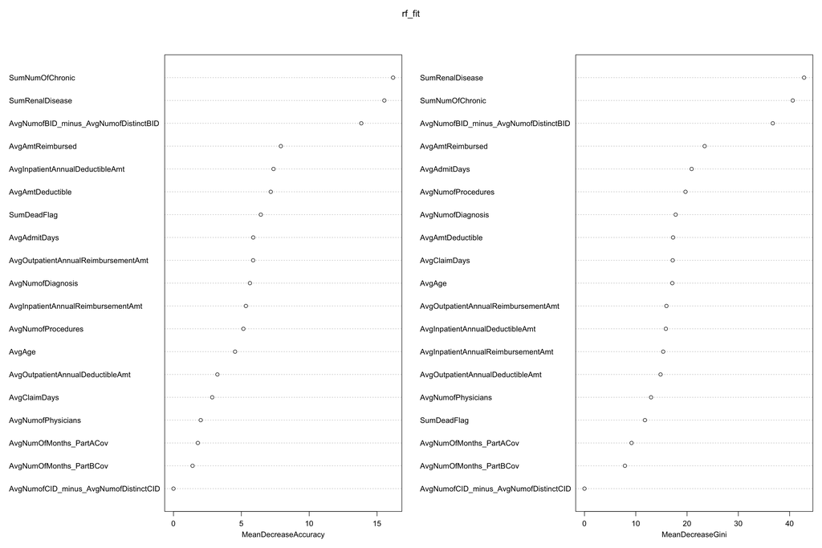

```r
varImpPlot(rf_fit)
```

```r
importance(rf_fit)
```

```
##                                              No         Yes
## AvgNumofCID_minus_AvgNumofDistinctCID  0.000000  0.00000000
## AvgNumofBID_minus_AvgNumofDistinctBID 13.230812  3.52523546
## AvgClaimDays                           1.427850  3.84654628
## AvgAdmitDays                           4.876126  7.11916060
## AvgNumofDiagnosis                      5.433551 -1.52864716
## AvgNumofProcedures                     3.139803  4.25310116
## AvgNumofPhysicians                     3.372249 -2.21524366
## AvgAmtReimbursed                       6.879916  4.83472753
## AvgAmtDeductible                       6.553178  0.54329940
## AvgAge                                 4.877876  0.24872051
## AvgNumOfMonths_PartACov                1.044847  2.28992240
## AvgNumOfMonths_PartBCov               -0.388340  3.46126753
## AvgInpatientAnnualReimbursementAmt     3.147952  2.74954809
## AvgInpatientAnnualDeductibleAmt        6.971174 -1.41780681
## AvgOutpatientAnnualReimbursementAmt    6.605773 -1.90250407
## AvgOutpatientAnnualDeductibleAmt       3.629432 -0.01983146
## SumRenalDisease                       13.870879  7.68719136
## SumDeadFlag                            6.006013  2.54483953
## SumNumOfChronic                       13.845031  7.18272742
##                                       MeanDecreaseAccuracy
## AvgNumofCID_minus_AvgNumofDistinctCID             0.000000
## AvgNumofBID_minus_AvgNumofDistinctBID            13.839924
## AvgClaimDays                                      2.852374
## AvgAdmitDays                                      5.873463
## AvgNumofDiagnosis                                 5.632839
## AvgNumofProcedures                                5.151947
## AvgNumofPhysicians                                2.006325
## AvgAmtReimbursed                                  7.911674
## AvgAmtDeductible                                  7.168132
## AvgAge                                            4.537815
## AvgNumOfMonths_PartACov                           1.795577
## AvgNumOfMonths_PartBCov                           1.405323
## AvgInpatientAnnualReimbursementAmt                5.335637
## AvgInpatientAnnualDeductibleAmt                   7.370612
## AvgOutpatientAnnualReimbursementAmt               5.868619
## AvgOutpatientAnnualDeductibleAmt                  3.235821
## SumRenalDisease                                  15.536400
## SumDeadFlag                                       6.434016
## SumNumOfChronic                                  16.181190
##                                       MeanDecreaseGini
## AvgNumofCID_minus_AvgNumofDistinctCID         0.000000
## AvgNumofBID_minus_AvgNumofDistinctBID        36.720142
## AvgClaimDays                                 17.200483
## AvgAdmitDays                                 20.892947
## AvgNumofDiagnosis                            17.779083
## AvgNumofProcedures                           19.695469
## AvgNumofPhysicians                           12.980558
## AvgAmtReimbursed                             23.430194
## AvgAmtDeductible                             17.272141
## AvgAge                                       17.122150
## AvgNumOfMonths_PartACov                       9.180388
## AvgNumOfMonths_PartBCov                       7.887303
## AvgInpatientAnnualReimbursementAmt           15.349851
## AvgInpatientAnnualDeductibleAmt              15.869325
## AvgOutpatientAnnualReimbursementAmt          15.983868
## AvgOutpatientAnnualDeductibleAmt             14.832776
## SumRenalDisease                              42.821768
## SumDeadFlag                                  11.786920
## SumNumOfChronic                              40.617074
```